# Score Computation Notebook

# Purpose

The purpose of this notebook is to use the raw travel time data to experiment with different methods of aggregation and score modeling.

## Import libraries

```r
library(tidyverse)
library(ggplot2)

# For pretty knitting
library(lemon)
knit_print.data.frame <- lemon_print
knit_print.tbl <- lemon_print
knit_print.summary <- lemon_print
```

## Import Scoring Functions

```r
source('Score_Functions.R')

# normalize_vec(vec, x=0.01, y=0.99, log = FALSE)
# normalize_df(df, x = 0.01, y = 0.99, log = FALSE)

# sum score function : SUM [i..n] (1 / (traveltime_i * std_traveltime_i) + ... ))
# sum_score_fxn(df, weight = FALSE, log_normalize_score = TRUE, normalize_df = FALSE, x=1, y=10)
```

```r
# function to plot score distributions by type
plot_densities <- function(score_frame1, score_frame2, titl1, titl2) {
  x <- score_frame1 %>%
        ggplot(aes(x = score, color = type)) +
        geom_density() +
        egg::theme_article() +
        theme(aspect.ratio = 0.3) +
        ggtitle(titl1)
  y <- score_frame2 %>%
        ggplot(aes(x = score, color = type)) +
        geom_density() +
        egg::theme_article() +
        theme(aspect.ratio = 0.3)+
        ggtitle(titl2)
  gridExtra::grid.arrange(x, y)
}
```

## Import data

```r
## Import raw Travel Time Matrix (ttm)
ttm <- read.csv('../../data/clean/ttm.csv')

n_origins <- 15197 # known origins
n_amenities <- 346 # known destinations from considered amenities

paste('Origins considered:', round(length(unique(ttm$fromId))/n_origins*100, 2), '%')
```

```
## [1] "Origins considered: 94.38 %"
```

```r
paste('Destinations considered:', round(length(unique(ttm$toId))/n_amenities*100, 2), '%')
```

```
## [1] "Destinations considered: 99.71 %"
```

```r
paste('Rows = ', nrow(ttm))
```

```
## [1] "Rows =  4172482"
```

```r
# convert Ids from double to factor
ttm$fromId <- as.factor(ttm$fromId)
ttm$toId <- as.factor(ttm$toId)

summary(ttm[,3:4])
```

```
##     avg_time         sd_time
##  Min.   :  0.00   Min.   : 1.000
##  1st Qu.: 50.59   1st Qu.: 1.847
##  Median : 70.95   Median : 2.719
##  Mean   : 71.70   Mean   : 3.235
##  3rd Qu.: 93.46   3rd Qu.: 4.017
##  Max.   :119.00   Max.   :35.355
```

## Data Wrangling

**Wrangling Notes:** - Remove skews and extreme values - Due to the diversity in amenity types (which all serve a unique cultural purpose), we’ll consider them independently for accessibility score computations. - Amenities which were interested in studying have already been filtered out in the ttm computation. They are the following: - Museums - Libraries - Galleries - Theatres

**Import and join amenity types**

```r
target_amenities <- c('gallery', 'museum', 'library or archives', 'theatre/performance and concert hall')
amenities <- read.csv('../../data/clean/vancouver_facilities_2.csv') %>% filter(type %in% target_amenities)

# preview original
sample_n(amenities, 3)
```

| id | lat | lon | type | name | city | city_id |
| --- | --- | --- | --- | --- | --- | --- |
| 2244 | 49.317592 | -123.0210051 | library or archives | Capilano University Archives | North Vancouver | 5915046 |
| 8653 | 49.280215 | -123.091958 | library or archives | Strathcona Branch | Vancouver | 5915022 |
| 268 | 49.20354979 | -122.9128583 | gallery | Amelia Douglas Gallery | New Westminster | 5915029 |

```r
# clean
amenities <- amenities[,c(1,4)] # only need id and type columns
amenities$id <- as.factor(amenities$id)     # convert to factor
amenities$type <- as.factor(amenities$type) # convert to factor

# preview clean
sample_n(amenities, 3)
```

| id | type |
| --- | --- |
| 5792 | library or archives |
| 4968 | gallery |
| 2169 | museum |

```r
# view summary
amenities %>% group_by(type) %>% summarise(count = n()) %>% arrange(desc(count))
```

Summary Table

| type | count |
| --- | --- |
| gallery | 99 |
| museum | 92 |
| library or archives | 88 |
| theatre/performance and concert hall | 75 |

```r
ttm <- ttm %>% left_join(amenities, by = c('toId' = 'id'))

summary(ttm[,3:4])
```

```
##     avg_time         sd_time
##  Min.   :  0.00   Min.   : 1.000
##  1st Qu.: 50.59   1st Qu.: 1.847
##  Median : 70.95   Median : 2.719
##  Mean   : 71.70   Mean   : 3.235
##  3rd Qu.: 93.46   3rd Qu.: 4.017
##  Max.   :119.00   Max.   :35.355
```

```r
sample_n(ttm, 5)
```

| fromId | toId | avg_time | sd_time | type |
| --- | --- | --- | --- | --- |
| 59153994001 | 6383 | 112.36840 | 2.259168 | library or archives |
| 59153997004 | 8777 | 16.00000 | 1.000000 | gallery |
| 59150097002 | 8809 | 116.28571 | 3.903600 | library or archives |
| 59151554002 | 5139 | 90.84615 | 5.309071 | library or archives |
| 59150132004 | 5967 | 80.97436 | 7.568936 | gallery |

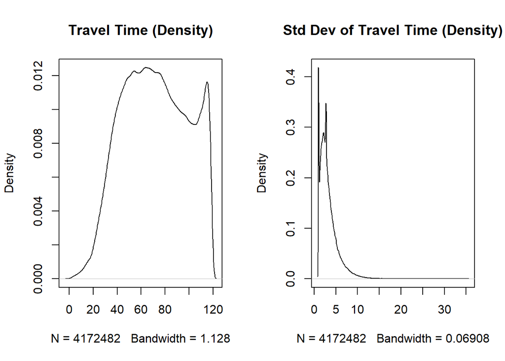

```r
par(mfrow = c(1,2))
plot(density(ttm[,3]), main = 'Travel Time (Density)')
plot(density(ttm[,4]), main = 'Std Dev of Travel Time (Density)')
```

**Replace travel times less than 5 minutes to 5 minutes**

This is done to prevent infinity values in the scoring. Normalization will be done to prevent zero values but it still creates a largely skewed score if we include travel times that approach zero. 5 minutes is also a realistic time window for any travel time that may take 0 - 5 minutes.

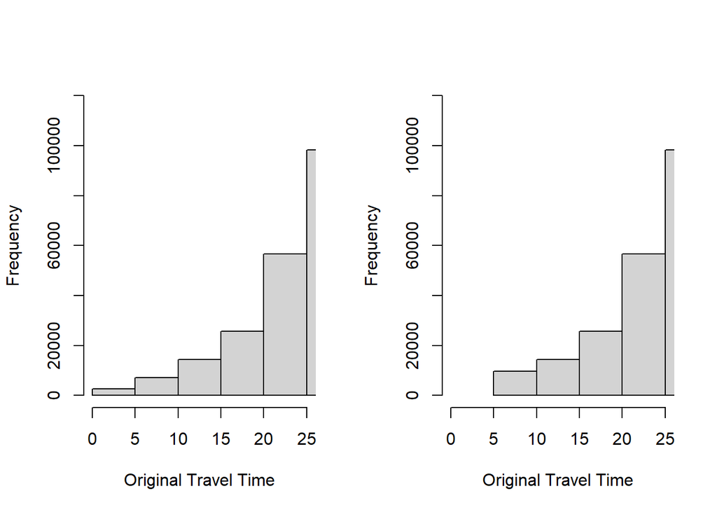

```r
par(mfrow = c(1, 2))
hist((ttm$avg_time), xlab = 'Original Travel Time', main = '',
     xlim = c(0, 25), ylim = c(0, 120000))

# set travel times <5 minutes to 5 minutes
min_5min <- pmax(ttm$avg_time, 5)
hist(min_5min, xlab = 'Original Travel Time', main = '',
     xlim = c(0, 25), ylim = c(0, 120000))
```

```r
ttm$avg_time <- min_5min
```

**Correct skew in standard deviation**

This will be important to prevent skew amplification in the score computation.

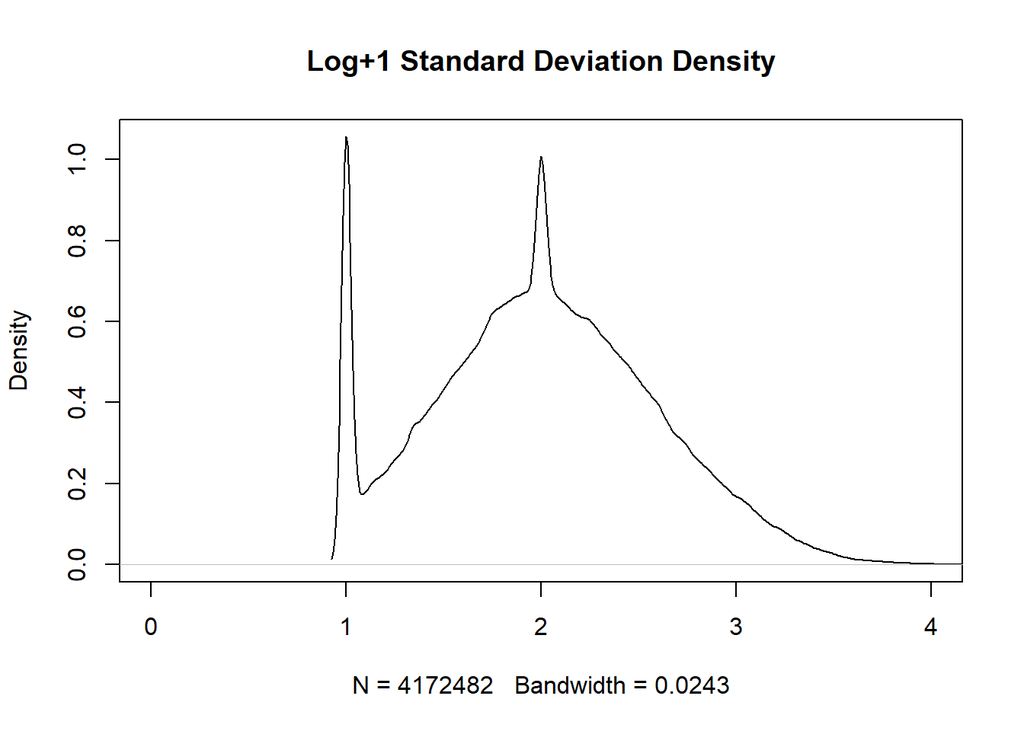

```r
# correct the skew in addition to edges close to zero
temp <- log(ttm$sd_time) + 1 # +1 just prevents zero values
plot(density(temp), main = 'Log+1 Standard Deviation Density', xlim = c(0,4))
```

```r
# set sd_unique_time to be the Log+1 corrected values
ttm$sd_time <- temp
```

## Add Amenity Weights

```r
# Import weight
dest_wts <- read.csv('../../data/amenity_score/poi_index.csv')

# clean
dest_wts <- dest_wts[, c(6,7)] # keep weight, id
names(dest_wts) <- c('weight', 'id')
dest_wts$id <-  as.factor(dest_wts$id)
head(dest_wts)
```

|  | weight | id |
| --- | --- | --- |
| 1 | 0.4715253 | 2292 |
| 2 | 0.6862229 | 2692 |
| 3 | 0.6713151 | 4546 |
| 4 | 0.5692166 | 6749 |
| 5 | 0.8031763 | 7153 |
| 6 | 0.5694037 | 7806 |

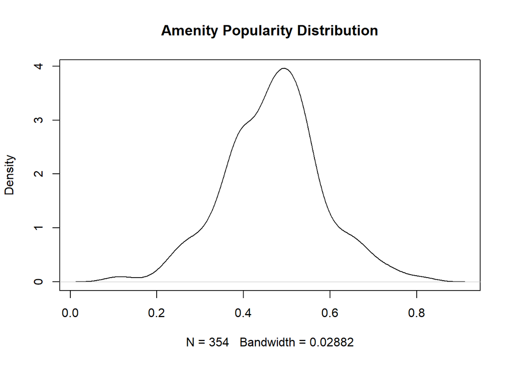

```r
# see weight distribution
plot(density(dest_wts$weight), main = 'Amenity Popularity Distribution')
```

```r
# join column
ttm_wts <- left_join(ttm, dest_wts, by = c('toId'='id'))

# If any weights are undefined replace with 1
ttm_wts$weight[is.na(ttm_wts$weight)] <- 1

head(ttm_wts)
```

|  | fromId | toId | avg_time | sd_time | type | weight |
| --- | --- | --- | --- | --- | --- | --- |
| 1 | 59150004004 | 10 | 99.76316 | 2.679844 | museum | 0.4829706 |
| 2 | 59150004004 | 15 | 72.48718 | 2.224303 | museum | 0.2669118 |
| 3 | 59150004004 | 157 | 96.69231 | 2.099062 | gallery | 0.5354125 |
| 4 | 59150004004 | 1759 | 106.82051 | 2.478922 | museum | 0.3589059 |
| 5 | 59150004004 | 1760 | 46.58974 | 1.971894 | gallery | 0.4060835 |
| 6 | 59150004004 | 1822 | 76.64103 | 2.383800 | museum | 0.6582380 |

## Sum Scoring Method

```r
# scores with [1 - 100] df normalization

ttm_scores <- sum_score_fxn(ttm_wts,
                            weight = FALSE,
                            log_normalize_score = TRUE,
                            normalize_df = TRUE, x = 1, y = 100)

ttm_wtd_scores <- sum_score_fxn(ttm_wts,
                            weight = TRUE,
                            log_normalize_score = TRUE,
                            normalize_df = TRUE, x = 1, y = 100)
```

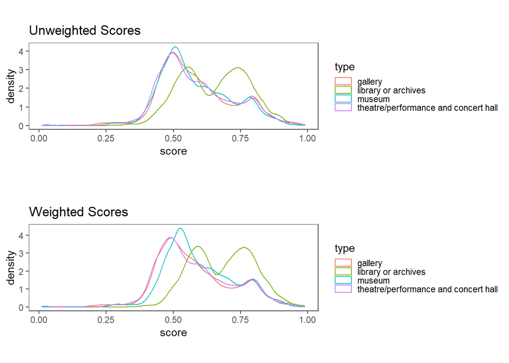

```r
plot_densities(ttm_scores, ttm_wtd_scores, 'Unweighted Scores', 'Weighted Scores')
```

```r
# scores with [0.01 - 0.99] df normalization

ttm_scores2 <- sum_score_fxn(ttm_wts,
                            weight = FALSE,
                            log_normalize_score = TRUE,
                            normalize_df = TRUE, x = 0.01, y = 0.99)
ttm_wtd_scores2 <- sum_score_fxn(ttm_wts,
                            weight = TRUE,
                            log_normalize_score = TRUE,
                            normalize_df = TRUE, x = 0.01, y = 0.99)
```

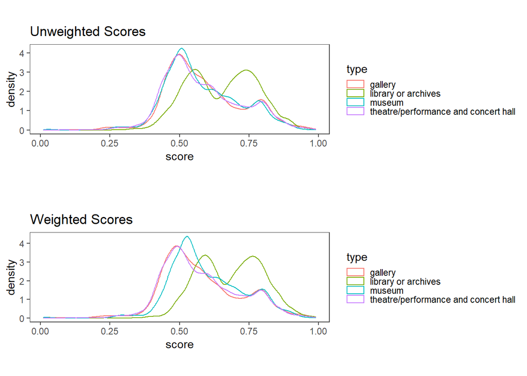

```r
plot_densities(ttm_scores2, ttm_wtd_scores2, 'Unweighted Scores', 'Weighted Scores')
```

## Sum Scoring for the Nearest 1, 2, or 3 Amenities

*Note that for nearest 1, the sum is the value itself.*

```r
# Keep only the nearest 1, 2, or 3 travel times for each dissemination block

nearest_1_ttm <- ttm_wts %>%
                  group_by(fromId, type) %>%
                  summarise(avg_time = min(avg_time),
                            sd_time = sd_time[which.min(avg_time)],
                            weight = weight[which.min(avg_time)])

nearest_2_ttm <- ttm_wts %>%
                  group_by(fromId, type) %>%
                  summarise(avg_time = na.omit(sort(avg_time)[1:2]),
                            sd_time = sd_time[which(na.omit(avg_time == sort(avg_time)[1:2]))],
                            weight = weight[which(na.omit(avg_time == sort(avg_time)[1:2]))])

nearest_3_ttm <- ttm_wts %>%
                  group_by(fromId, type) %>%
                  summarise(avg_time = na.omit(sort(avg_time)[1:3]),
                            sd_time = sd_time[which(na.omit(avg_time == sort(avg_time)[1:3]))],
                            weight = weight[which(na.omit(avg_time == sort(avg_time)[1:3]))])


# scores by nearest amenities

n1_ttm_score <- sum_score_fxn(nearest_1_ttm, weight = FALSE, log_normalize_score = TRUE, normalize_df = TRUE, x = 1, y = 100)
n1_wt_ttm_score <- sum_score_fxn(nearest_1_ttm, weight = TRUE, log_normalize_score = TRUE, normalize_df = TRUE, x = 1, y = 100)

n2_ttm_score <- sum_score_fxn(nearest_2_ttm, weight = FALSE, log_normalize_score = TRUE, normalize_df = TRUE, x = 1, y = 100)
n2_wt_ttm_score <- sum_score_fxn(nearest_2_ttm, weight = TRUE, log_normalize_score = TRUE, normalize_df = TRUE, x = 1, y = 100)

n3_ttm_score <- sum_score_fxn(nearest_3_ttm, weight = FALSE, log_normalize_score = TRUE, normalize_df = TRUE, x = 1, y = 100)
n3_wt_ttm_score <- sum_score_fxn(nearest_3_ttm, weight = TRUE, log_normalize_score = TRUE, normalize_df = TRUE, x = 1, y = 100)
```

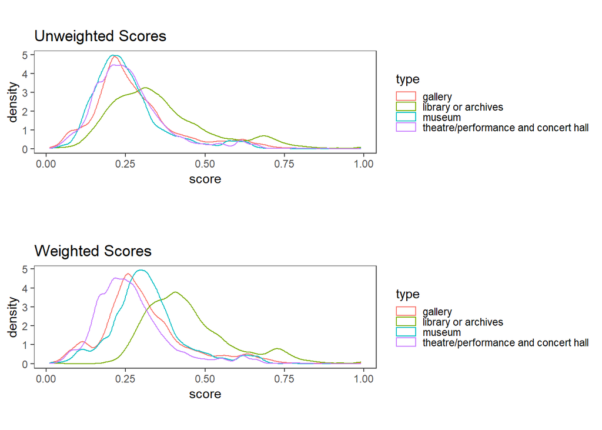

```r
plot_densities(n1_ttm_score, n1_wt_ttm_score, 'Unweighted Scores', 'Weighted Scores')
```

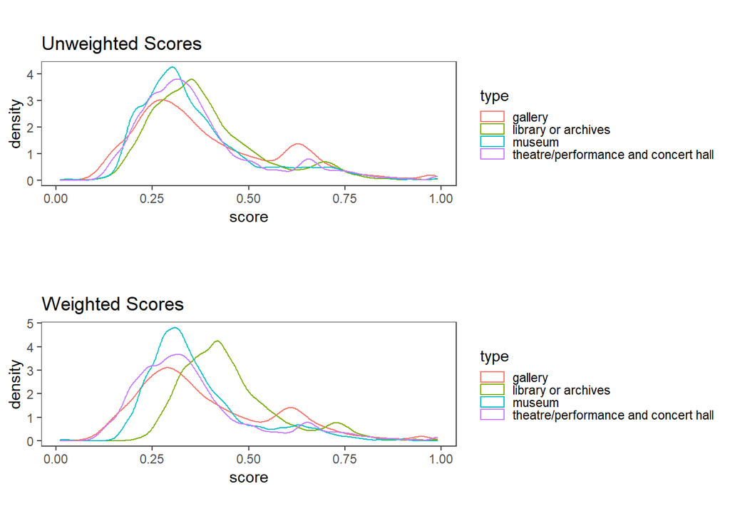

```r
plot_densities(n2_ttm_score, n2_wt_ttm_score, 'Unweighted Scores', 'Weighted Scores')
```

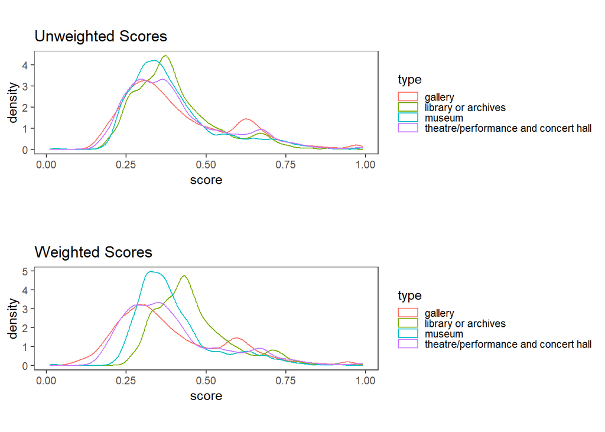

```r
plot_densities(n3_ttm_score, n3_wt_ttm_score, 'Unweighted Scores', 'Weighted Scores')
```

## Exporting all Score Sets

```r
## Add weight column for each score frame

ttm_scores$weight <- as.factor('no')
ttm_wtd_scores$weight <- as.factor('yes')

n1_ttm_score$weight <- as.factor('no')
n1_wt_ttm_score$weight <- as.factor('yes')

n2_ttm_score$weight <- as.factor('no')
n2_wt_ttm_score$weight <- as.factor('yes')

n3_ttm_score$weight <- as.factor('no')
n3_wt_ttm_score$weight <- as.factor('yes')

## Add nearest_n column for each score frame

ttm_scores$nearest_n <- as.factor('all')
ttm_wtd_scores$nearest_n <- as.factor('all')

n1_ttm_score$nearest_n <- as.factor('1')
n1_wt_ttm_score$nearest_n <- as.factor('1')

n2_ttm_score$nearest_n <- as.factor('2')
n2_wt_ttm_score$nearest_n <- as.factor('2')

n3_ttm_score$nearest_n <- as.factor('3')
n3_wt_ttm_score$nearest_n <- as.factor('3')

## Combine into a long dataframe
all_scores <- list(ttm_scores, ttm_wtd_scores,
                   n1_ttm_score, n1_wt_ttm_score,
                   n2_ttm_score, n2_wt_ttm_score,
                   n3_ttm_score, n3_wt_ttm_score)

long_scores <- data.table::rbindlist(all_scores) %>% arrange(fromId)

## Re-Order columns
long_scores <- long_scores[, c(1, 2, 4, 5, 3)]

## Export
write.csv(long_scores, '../../data/score_sets/long_scores.csv', row.names = FALSE)
```

# Old Notes ~ Ignore or reuse later

| Name | Function | Notes | Assumptions |
| --- | --- | --- | --- |
| Unweighted Naive | number of accessible points / (mean transit time * mean standard deviation in transit time) | Mean transit time to all accessible destinations | Assumes that accessibility is defined by access to all amenities |
| Weighted Naive | popularity weighted accessible points / (mean transit time * mean standard deviation in transit time) | Mean transit time to all accessible destinations | Assumes that accessibility is defined by access to all amenities and that amenity popularity defines significance of an accessible amenity |
| Unweighted Sum | 1 / (nearest amenity transit time + standard deviation in nearest transit time) | Only considers the nearest 1 to 3 amenities of a certain category. Sum is used to prevent skewing of data (difference(1/(0.01*0.01) and 1/(6*6)) >>> difference(1/(0.01+0.01) and 1/(6+6))) | Assumes accessibility only defined by access to the nearest amenity type |
| Joseph Unweighted Sum | sum(1 / (normalized_transit_time_i*normalized_sd_time_i)) | Sums the transit times as opposed to taking the mean, then normalizes the scores. |  |